# SARCs and Annual Crime Data

Natalie J. Reyes

2023-12-11

# SARCs versus Rape Crisis Centres

A few lines on what SARCs are and how they differ from Rape Crisis Centres.

1. SARC | Sexual Assault Referral Centres

These centres are funded and run by the National Health Service (NHS). This means that they are part of the public healthcare system in the UK.

Scope: They are primarily focused on providing immediate medical care, including forensic examinations, and support in the aftermath of a sexual assault. They also offer emergency contraception and sexual health advice.

Support with police reporting: They offer assistance in reporting sexual assault to the police, including the option to store forensic evidene while the individual decides whether to report.

2. Rape Crisis Centres

These centres are typically run as charitable organizations. They operate under umbrella organizations like Rape Crisis England and Rape Crisis Scotland.

Scope: They provide a broader range of services including crisis support, advocacy, and long-term psychological support to survivors of all forms of sexual violence and abuse. They do not typically offer medical services.

Support with police reporting: While they may assist with the process, their primary focus is not on facilitating police reporting or evidence collection.

# Map of SARCs & Police Stations

A map of all the SARCs (points) with the police station boundaries (polygons) you found. Please have a colour gradient where the stations polygons with the higher crime levels are shaded in a darker colour, like a heat map.

```r
# Load necessary libraries
library(sf)
```

```
## [1] "British Transport"                  "Police Service of Northern Ireland"
## [1] "Greater Manchester"
```

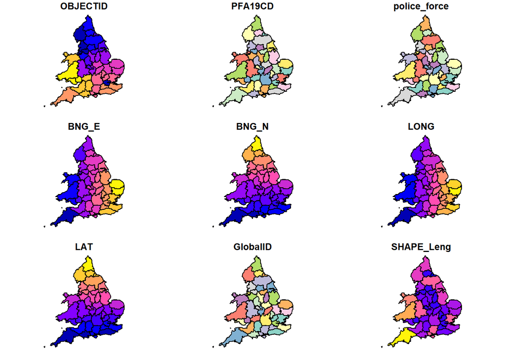

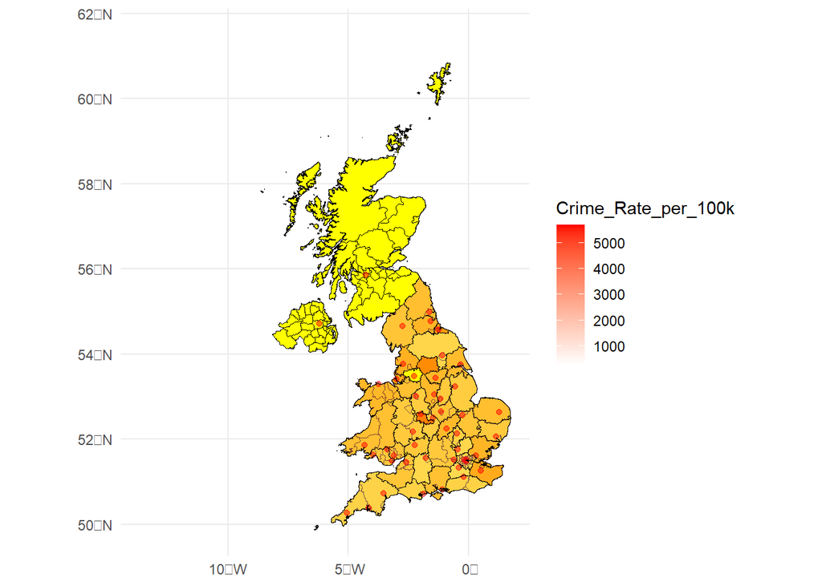

```r
library(ggplot2)
source("C:/Users/natal/Desktop/GitHub/SARC_research/SARCmap.R")
```

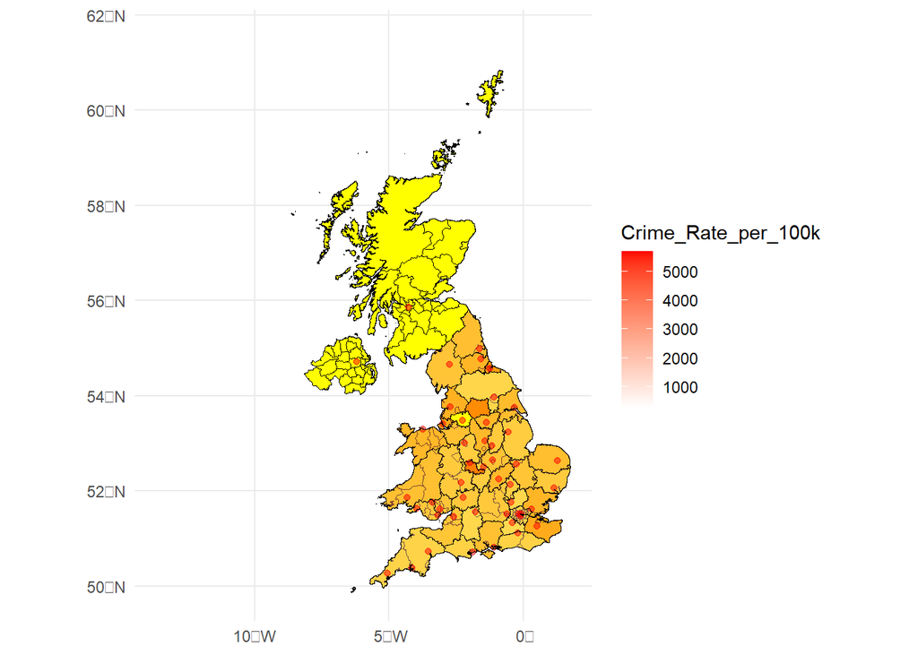

```r
# Map of Neighborhood Level Crime Rates for 2021

#Another map of neighbourhood level crime rates per 100,000 for 2021.

print(map_with_overlays_and_heat)
```

```
## Unique Crime Types for 2012 :
##  [1] "Anti-social behaviour"       "Other theft"
##  [3] "Vehicle crime"               "Burglary"
##  [5] "Criminal damage and arson"   "Shoplifting"
##  [7] "Violent crime"               "Drugs"
##  [9] "Other crime"                 "Public disorder and weapons"
## [11] "Robbery"
##
## Unique Police Neighborhoods for 2012 :
##  [1] "Avon and Somerset Constabulary"     "Bedfordshire Police"
##  [3] "British Transport Police"           "Cambridgeshire Constabulary"
##  [5] "Cheshire Constabulary"              "City of London Police"
##  [7] "Cleveland Police"                   "Cumbria Constabulary"
##  [9] "Derbyshire Constabulary"            "Devon & Cornwall Police"
## [11] "Dorset Police"                      "Durham Constabulary"
```

[output cut: 396 more lines]

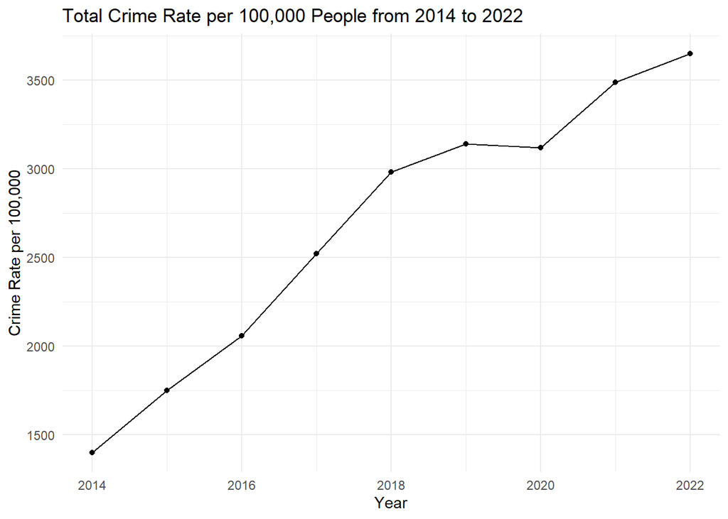

```
##                          police_force Total_Crimes Crime_Rate_per_100k
## 1      Avon and Somerset Constabulary        56220           3407.2727
## 2                 Bedfordshire Police        19500           2934.5372
## 3            British Transport Police        10414                  NA
## 4         Cambridgeshire Constabulary        27547           3443.3750
## 5               Cheshire Constabulary        39400           3682.2430
## 6               City of London Police         1084            251.5081
## 7                    Cleveland Police        29547           5183.6842
## 8                Cumbria Constabulary        17114           3436.5462
## 9             Derbyshire Constabulary        42344           3994.7170
## 10            Devon & Cornwall Police        47329           2689.1477
## 11                      Dorset Police        21564           2775.2896
## 12                Durham Constabulary        26962           4206.2402
## 13                 Dyfed-Powys Police        19313           3692.7342
## 14                       Essex Police        77751           4180.1613
```

[output cut: 30 more lines]

```r
# Annual Crime Rates (per 100,000)

library(ggplot2)
source("C:/Users/natal/Desktop/GitHub/SARC_research/Annual_Police_Data.R")
```

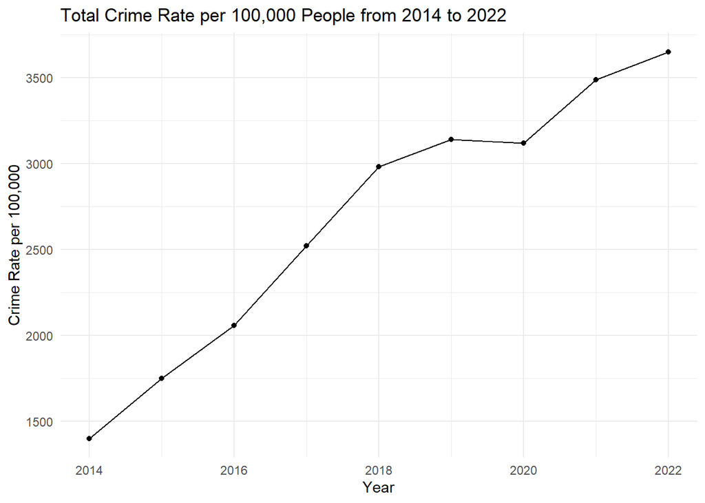

```r
print(crime_rate_over_years_plot)
```